# CHAPTER A26

# 弾性および熱弾性における選択された問題

## A26.1 はじめに

前章では、弾性および熱弾性の二次元方程式の一般的な定式化を示した。本章では、梁の章で議論される材料力学的なアプローチではなく、これらの方程式を用いて、弾性および熱弾性における簡単な問題の解法を展開することに専念する。これらの問題は、選択された数学的モデルに対する支配方程式の定式化、これらの方程式の解法、および結果の解釈を明確に示すために選択されている。このような問題は、特に本章の最後に言及されている等温解析の場合、文献に数多く存在する。したがって、本章で選択された問題は手法を説明するためだけのものであり、一部の読者には些細に見えるかもしれないが、文献を容易かつ自信を持って読めるように、手法に関する合理的にしっかりした知識を提供することを意図している。本章のすべての問題において、A24章の基本仮定が遵守されているため、議論は温度によって特性が影響を受けない弾性材料に限定される。

本章は、金属が加熱されたときの挙動、および弾性定数が温度上昇によって影響を受けないことを学生に理解してもらうためだけに、この時点で挿入された簡単な一次元問題の選択から始まる。このセクションに続いて、前章の定式化を用いた問題が選択されている。

## A26.2 一次元問題

### 例1

図 A26.1 に示すように、2つの剛体壁の間に取り付けられた金属の円柱状の棒を考える。

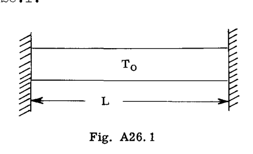

図 A26.1

初期温度 $T_0$ における棒の幾何学的特性は、断面積 $A$ と長さ $L$ によって完全に規定されている。唯一の拘束は、剛体壁によって長さ $L$ に課されるものである。問題は、温度が $T$ に上昇したときの棒全体の応力分布と形状の変化を求めることである。

加熱中に棒が拘束されていないと仮定する。長さの変化は次式のようになる。

$$\Delta L = \alpha(T - T_0)L$$

または、新しく加熱された全長さは次式のようになる。

$$L_1 = L[1 + \alpha(T - T_0)]$$

ここで、 $T - T_0 =$ 温度変化

$$\begin{aligned}
\alpha &= \text{線熱膨張係数} \\
&= \text{温度1度変化あたりの単位長さあたりの長さの変化} \\
&\quad \text{（選定された基準温度において）}
\end{aligned}$$

工学においては、温度変化を $^\circ\text{F}$ で測定し、基準温度として $32^\circ\text{F}$ を使用するのが一般的である。 $\alpha$ が定数である限り、上記の定義により $\alpha$ の値は同じになるため、基準温度は元の温度と同様に自由に選択できる。しかし、ほとんどの材料において、 $\alpha$ は温度の係数（関数）であるため、下表に示されている値は、規定された温度範囲にのみ適用可能である。

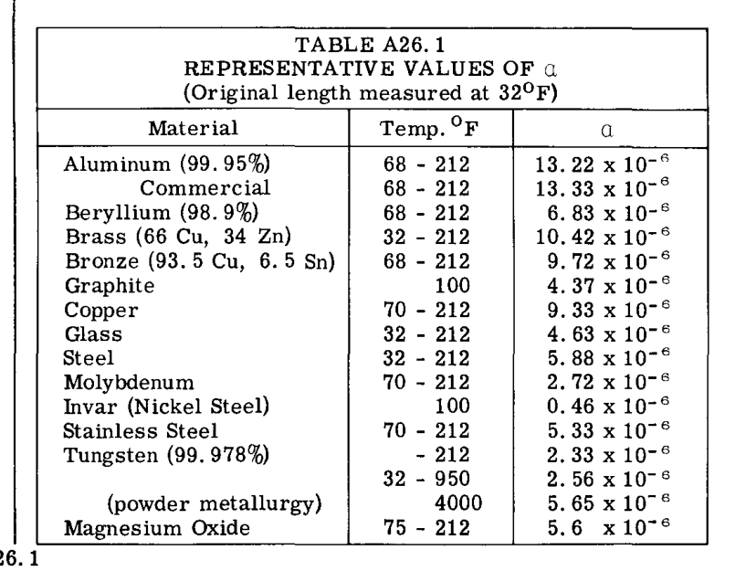

TABLE A26.1

さらに、示された材料のすべての合金が特徴的な $\alpha$ を持っている。したがって、この表は $\alpha$ の適切な値へのガイドとしてのみ使用でき、正確な値はより広範な資料から入手する必要がある。

さて、議論している例では、剛体壁の間に収まるように、棒を $\Delta L$ だけ圧縮する必要があることがわかる。これにより、軸方向に $\Delta L/L$ の圧縮ひずみ、すなわち

$$\varepsilon = -\alpha(T - T_0)$$

が生じ、圧縮応力は

$$\sigma = -E\alpha(T - T_0)$$

となる。

ポアソン効果による弾性ひずみと同様に、半径方向の熱膨張も発生する。しかし、この方向には拘束も膨張もなく、表面力も作用しないため、半径方向の応力は発生しない。したがって、壁に対する端部で半径方向の変形に対する拘束が存在しない場合、かつその場合に限り、棒の全長にわたって断面上に均一に分布した圧縮応力が存在する。壁に対して作用する全荷重は次のようになる。

$$P = -E\alpha(T - T_0)A_1$$

ここで $A_1$ は最終的な断面積であり、材料が大きな $\alpha$ 値を持ち、温度上昇が大きい場合、この断面積の変化は $P$ の計算において重要になる可能性がある。ポアソン効果は通常無視できる。問題 26.1 で $A_1$ を求めることは学生への演習として残されている。

### 例2

剛体で摩擦のない壁の間に支持され、壁の間に完全にフィットしていたときの周囲温度 $T_0$ から温度 $T$ に加熱された2つの円柱状の棒のシステムを考える。システムは以下の図 A26.2 に示されている。

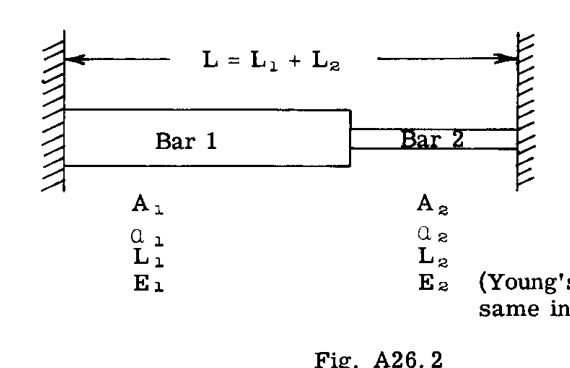

図 A26.2

各棒の幾何学的特性および線熱膨張係数は異なる。問題は、半径方向の拘束がなく、表面力がないという仮定の下で、各棒の軸応力と界面の変位を求めることである。

再び、一方の端部から拘束を取り除く。全膨張は次式のようになる。

$$\Delta L = \alpha_1 L_1(T - T_0) + \alpha_2 L_2(T - T_0)$$

そして、この全変位が取り除かれるように、棒は共通の力 $P$ によって圧縮されなければならない。

棒1の応力は $\sigma_1 = \frac{-P}{A_1}$ となり、棒2の応力は $\sigma_2 = \frac{-P}{A_2}$ となる。

対応するひずみは

$$\varepsilon_1 = -\frac{P}{A_1 E}$$

および

$$\varepsilon_2 = -\frac{P}{A_2 E}$$

となる。

対応する各棒の変位、すなわち長さの変化は

$$u_1 = -\frac{P}{A_1 E} L_1$$

および

$$u_2 = -\frac{P}{A_2 E} L_2$$

となる。今、

$$u_1 + u_2 = \Delta L$$

であるから、

$$-P \left[ \frac{L_1}{A_1 E} + \frac{L_2}{A_2 E} \right] = (\alpha_1 L_1 + \alpha_2 L_2)(T - T_0)$$

または

$$P = -\frac{(\alpha_1 L_1 + \alpha_2 L_2)(T - T_0)}{\left( \frac{L_1}{A_1 E} + \frac{L_2}{A_2 E} \right)}$$

これより以下のように従う。

$$\sigma_1 = -\frac{(\alpha_1 L_1 + \alpha_2 L_2)(T - T_0)}{\left( \frac{L_1}{E} + \frac{L_2 A_1}{A_2 E} \right)}$$

および

$$\sigma_2 = -\frac{(\alpha_1 L_1 + \alpha_2 L_2)(T - T_0)}{\left( \frac{A_2 L_1}{A_1 E} + \frac{L_2}{E} \right)}$$

界面の最終位置は、左側の壁から距離 $x$ に位置し、棒1の元の長さプラスその熱伸びプラス $u_1$ で与えられる。すなわち、

$$x = L_1 + \alpha_1 L_1(T - T_0) - \frac{\frac{L_1}{E}(\alpha_1 L_1 + \alpha_2 L_2)(T - T_0)}{\left( \frac{L_1}{E} + \frac{A_1 L_2}{A_2 E} \right)}$$

この問題が本質的にそれほど単純ではないことは興味深いことである。この解析では、各棒の断面にわたって界面応力分布が均一であるという仮定が必要である。棒1の場合、これは確かに当てはまらない。この二次元応力場を考慮に入れた問題への拡張は、本章の範囲を超えている。この効果は、 $A_1/A_2$ の比が大きく、また $P$ の値が大きい場合を除き、すべての場合に無視できることに留意すれば十分である。

この明白な問題の拡張のほかに、以下の有意義な研究が考えられる。

1. 簡単な柱システムの安定性の調査、および
2. 一方または両方の材料の非常に高い温度における流動挙動の調査。

これらの重要かつ困難な側面は、後の章で再び取り上げる。

### 例3

同じ問題を、システムが完全に拘束されていない状態から始めて、元の、あるいは定義された形状を復元するために必要な荷重を決定するという手法を必要としない、より直接的な方法で分析する。この述べられた手法は、A24.4章およびA24.5章で最も望ましいものとして議論されてきたが、直接的なアプローチの方が合理的な場合もあり、したがって見落としてはならない。この問題は、熱弾性理論の展開の現段階における優れた比較例となる。

図 A26.3 を考える。これは図 A26.2 と同じであるが、正の座標系、境界条件、および考えられる変形後の位置を示している。

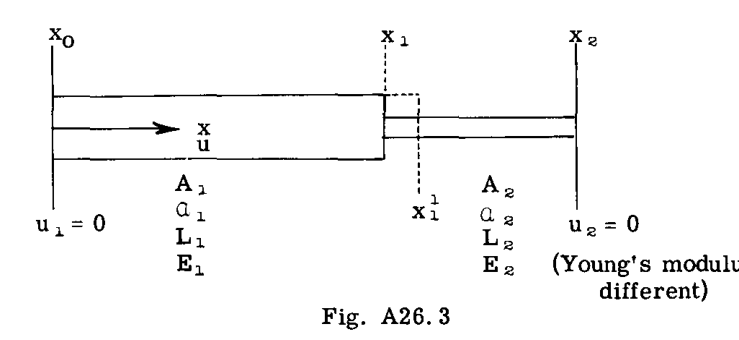

図 A26.3

システムにおける全ひずみは次式のようになる。

$$\varepsilon_x = \varepsilon_{x_1} + \varepsilon_{x_2}$$

ここで、

$$\varepsilon_{x_1} = \frac{\sigma_{x_1}}{E_1} + \alpha_1(T - T_0)$$

および

$$\varepsilon_{x_2} = \frac{\sigma_{x_2}}{E_2} + \alpha_2(T - T_0)$$

ひずみ-変位関係から、この場合 $u$ は $x$ のみの関数であるため、

$$\varepsilon_{x_1} = \frac{du_1}{dx}$$

$$\varepsilon_{x_2} = \frac{du_2}{dx}$$

したがって、次のように従う。

$$u_1 = \int_0^{x_1} \left[ \frac{\sigma_{x_1}}{E_1} + \alpha_1(T - T_0) \right] dx$$

および

$$u_2 = \int_{x_1}^{x_2} \left[ \frac{\sigma_{x_2}}{E_2} + \alpha_2(T - T_0) \right] dx$$

しかし、界面がそのまま維持され、全体の伸びが許されないならば、 $u_1 + u_2 = 0$ である。さらに、各棒をとおして同じ力が伝達されるため、

$$\sigma_{x_1} A_1 = \sigma_{x_2} A_2$$

したがって、

$$\int_0^{x_1} \left[ \frac{\sigma_{x_1}}{E_1} + \alpha_1(T - T_0) \right] dx + \int_{x_1}^{x_2} \left[ \frac{\sigma_{x_1} A_1}{E_2 A_2} + \alpha_2(T - T_0) \right] dx = 0$$

$\sigma_x, E_1, E_2, A_1, A_2, \alpha_1, \alpha_2$ はシステム全体で定数であるため、この場合の積分は単純であり、 $0 \to x_1 = L_1$ および $x_1 \to x_2 = L_2$ であるから、

$$\frac{\sigma_{x_1}}{E_1} L_1 + \alpha_1(T - T_0)L_1 + \frac{\sigma_{x_1} A_1}{E_2 A_2} L_2 + \alpha_2(T - T_0)L_2 = 0$$

これより次式が直接従う。

$$\sigma_{x_1} = -\frac{(\alpha_1 L_1 + \alpha_2 L_2)(T - T_0)}{\left( \frac{L_1}{E_1} + \frac{L_2 A_1}{E_2 A_2} \right)}$$

$$\sigma_{x_2} = -\frac{(\alpha_1 L_1 + \alpha_2 L_2)(T - T_0) \frac{A_1}{A_2}}{\left( \frac{L_1}{E_1} + \frac{L_2 A_1}{E_2 A_2} \right)}$$

および

$$u_1 = -u_2 = \alpha_1 L_1(T - T_0) - \frac{\frac{L_1}{E_1}(\alpha_1 L_1 + \alpha_2 L_2)(T - T_0)}{\left( \frac{L_1}{E_1} + \frac{A_1 L_2}{A_2 E_2} \right)}$$

これは前と同じである。この直接的なアプローチの固有の利点は、断面形状の起こり得る変化や、軸方向の物理的特性の変化を考慮するための問題の一般化が容易なことである。

### 例4

前述の例の直接的な応用は、ボルト継手のボルトに発生するせん断応力および引張応力の決定である。周囲温度 $T_0$ より高い異なる温度 $T_1$ および $T_2$ に加熱された2つの異なる金属間のボルト継手を考える。初期のボルト隙間は、通常、熱応力を緩和するためにボルト継手において許容されており、そのような隙間は図 A26.4 に $C_1$ および $C_2$ として示されている。

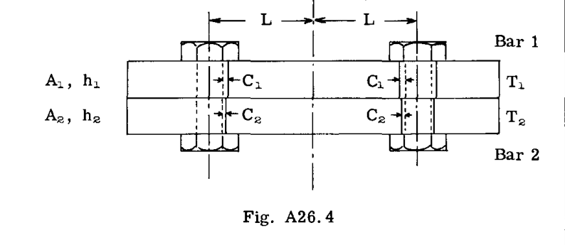

図 A26.4

棒1および棒2に関連する材料定数は、それぞれ $E_1, \alpha_1$ および $E_2, \alpha_2$ である。

#### 伝達されるせん断荷重の決定

対称性のため、上記システムの片側のみを考慮すればよい。 $T_1 > T_2$ かつ $\alpha_1 > \alpha_2$ と仮定する（他の組み合わせへの一般化は単純であり、同じ展開に従う）。

ボルトが取り外されていると仮定する。

棒1は、孔の中心線の変位量 $\alpha_1(T_1 - T_0)L$ だけ膨張する。

棒2は、量 $\alpha_2(T_2 - T_0)L$ だけ膨張する。

したがって、孔の中心線の相対変位は次式のようになる。

$$\alpha_1(T_1 - T_0)L - \alpha_2(T_2 - T_0)L$$

許容される隙間は $C_1 + C_2$ であるため、ボルトがちょうどフィットするように孔を再整列させるために必要な2つの棒の間の相対変位は、次式で与えられる。

$$-\alpha_1(T_1 - T_0)L + \alpha_2(T_2 - T_0)L + (C_1 + C_2)$$

この運動のすべてが棒1を圧縮することによって得られ、ボルトを挿入し、その後システムを解放すると、2つの棒は一緒に膨張して、それぞれに同じ力 $P$ が存在する平衡位置に達する。ピンを挿入した後の予圧縮された棒1の全運動は、

$$\left[ \alpha_1(T_1 - T_0)L - \alpha_2(T_2 - T_0)L - (C_1 + C_2) \right] - \frac{PL}{E_1 A}$$

となり、棒2の運動は $\frac{PL}{E_2 A_2}$ となる。これらの運動は同じでなければならないため、次式が直接従う。

$$P = \frac{\alpha_1(T_1 - T_0) - \alpha_2(T_2 - T_0) - \frac{(C_1 + C_2)}{L}}{\left( \frac{1}{A_1 E_1} + \frac{1}{A_2 E_2} \right)}$$

この選択されたケースでは、棒1の膨張が最初は棒2の膨張よりも大きく、この相対膨張が全隙間よりも大きいと仮定されたため、 $P$ は棒1に圧縮を、棒2に引張を生じさせる。これは、そもそも熱応力が発生するために当然必要である。解は次のように一般化されるべきである。

$$P = \frac{\pm \alpha_1(T_1 - T_0) \mp \alpha_2(T_2 - T_0) - \frac{(C_1 + C_2)}{L}}{\left( \frac{1}{A_1 E_1} + \frac{1}{A_2 E_2} \right)}$$

そして、適切な符号は、相対変位の初期予測から選択される。ボルトの配列におけるボルトの弾性変形を考慮に入れることは、この問題の興味深い拡張である。

ボルトの引張荷重（ボルトの予張力に加算される）は、次のように導くことができる。ボルト軸方向の棒の全膨張は（熱膨張による）、各板において以下のようになる。

$$\alpha_1(T_1 - T_0)h_1 \quad \text{および} \quad \alpha_2(T_2 - T_0)h_2$$

しかし、ボルトの増加した引張力 $P$ による弾性収縮が発生し、それはそれぞれ

$$P \left( \frac{h_1}{E_1 A_1} \right) \quad \text{および} \quad P \left( \frac{h_2}{E_2 A_2} \right)$$

となる。ここで $A_1$ および $A_2$ は、ボルトの張力によって影響を受ける仮想的な棒の領域である。この領域の一般的に使用される推定値は、ボルト中心線の周りの2つのボルト直径の円に含まれる領域である。したがって、ボルト軸方向の全棒変形は次のようになる。

$$\alpha_1(T_1 - T_0)h_1 + \alpha_2(T_2 - T_0)h_2 - \frac{Ph_1}{E_1 A_1} - \frac{Ph_2}{E_2 A_2}$$

今、ボルトの温度が $T_3$ であると仮定すると、ボルトの全伸びは次のようになる。

$$\alpha_B(T_3 - T_0)(h_1 + h_2) + \frac{P}{E_B} \frac{(h_1 + h_2)}{A_B}$$

ここで、下付き文字 B はボルトを指す。

これらの伸びは、当然同じでなければならず、したがって

$$P = \frac{\alpha_1(T_1 - T_0)h_1 + \alpha_2(T_2 - T_0)h_2 - \alpha_B(T_3 - T_0)(h_1 + h_2)}{\frac{h_1 + h_2}{E_B A_B} + \frac{h_1}{E_1 A_1} + \frac{h_2}{E_2 A_2}}$$

この最後の公式を、温度が長さに沿って変化する複数の層、変化する直径のボルトなどに拡張することは、これまでの展開およびボルト軸に沿って変化する温度に適用される例3の議論から明らかである。

### 例5

熱応力を避けるために主要構造を設計することが比較的一般的になりつつある。これを行うための明白な方法の1つは、通常のフランジ付き翼梁を静定トラスに置き換えることである。なぜなら、トラスシステム全体の熱膨張に拘束が課されない限り、そのような構造には熱応力が存在し得ないからである。

波形ウェブの使用は、熱応力を緩和するために設計された構造技術の1つの例である。しかし、このような構造では、熱ひずみ、したがって、たわみが大きくなるため、考慮しなければならない。

不静定構造は、幾何学的な拘束が課されていない場合でも、不均一な加熱が存在するときはいつでも熱応力を含む。個々の部材が異なる温度にある静定でないトラスまたは立体フレームの場合、解析は、容易に計算された熱ひずみおよびたわみが初期変形として導入される等温問題と同じである。この問題は、A8章のA8.9節で詳細に説明されているため、ここでは取り扱わない。

次に、A25章の二次元定式化が必要となる、板や梁などの連続構造に注目する。

## A26.3 二次元問題

### 例1

最初の例として、外部から曲げモーメントを受け、システム全体が室温にある単純な梁の問題を考えてみよう。物理的なシステムは、以下の図 A26.5 に示されている。

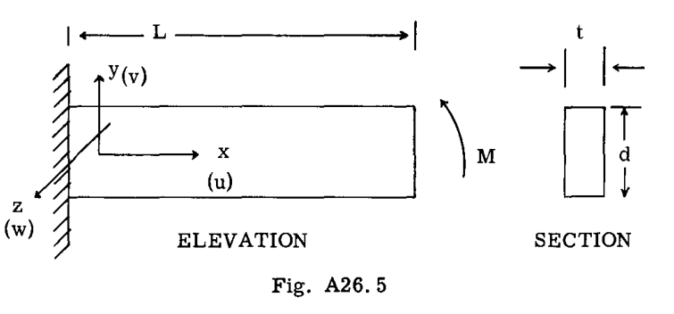

図 A26.5

問題は、示された正の端部モーメントの影響下での、梁全体の応力、ひずみ、および変位分布を求めることである。数学的モデルは、幾何学的には図 A26.5 に示されているものと同じであるが、以下の仮定を伴う。

1. $x-y$ 平面外への変位はない、すなわち $w = 0$ 。
2. すべての変形は小さく、基本定式化の方程式が適用される。
3. 梁は薄い（ $t$ は小さい）ため、作用するモーメントは $x-y$ 平面内にあり、梁の側面には表面力が存在しない。したがって、 $z$ 方向の応力成分は存在しない。
4. 体積力は存在しない、すなわち $X = Y = Z = 0$ 。

仮定(3)から、すべての応力は $x-y$ 平面内にあり、したがって問題は平面応力状態の1つであることが明らかである。（たまたま、この時点では単に便宜上適用されている仮定(2)の下では、問題は平面ひずみ状態でもある。）

問題は今、平衡方程式、適合方程式、および境界条件を満たす $\sigma_x, \sigma_y$ および $\tau_{xy}$ に対する応力関数を決定することである。基本方程式は以下の通りである。

$$\left. \begin{aligned}
\frac{\partial\sigma_x}{\partial x} + \frac{\partial\tau_{xy}}{\partial y} &= 0 \\
\frac{\partial\sigma_y}{\partial y} + \frac{\partial\tau_{xy}}{\partial x} &= 0
\end{aligned} \right\} \quad \text{平衡}$$

$$\frac{\partial^2\gamma_{xy}}{\partial x\partial y} = \frac{\partial^2\varepsilon_x}{\partial y^2} + \frac{\partial^2\varepsilon_y}{\partial x^2} \quad \text{適合}$$

および境界条件

$$\int_{-\frac{d}{2}}^{\frac{d}{2}} t \sigma_x dy = 0 \quad \text{（作用する端部推力はゼロ）}$$

$$\int_{-\frac{d}{2}}^{\frac{d}{2}} t \sigma_x y dy + M = 0 \quad \text{（モーメントの和 = 0）}$$

仮定(3)より

$$\sigma_z = \tau_{xz} = \tau_{yz} = 0$$

したがって

$$\varepsilon_z = \gamma_{xz} = \gamma_{yz} = 0$$

外力は曲げのみであり、 $x$ 方向の変形はないため、ひずみ分布は次の形式であると仮定するのが妥当である。

$$\varepsilon_x = C_0 + C_1 y \quad \text{（平面は平面のまま保たれる）}$$

$$\varepsilon_y = f(y)$$

したがって

$$\sigma_x = E(C_0 + C_1 y)$$

$$\sigma_y = E f(y)$$

第1の平衡方程式から、 $\tau_{xy}$ は定数であるか、または $x$ のみの関数でなければならない。次に、第2の平衡方程式から、

$$\frac{\partial\sigma_y}{\partial y} = -\frac{\partial\tau_{xy}}{\partial x}$$

または

$$E \frac{df(y)}{dy} = 0 \quad \text{（定数または } x \text{ の関数）}$$

荷重の対称性により、最後の可能性は存在せず、第2の可能性は $f(y)$ が $y$ の線形関数であることを許容し、第3は $f(y)$ が定数であることを許容する。 $\sigma_y$ 成分と釣り合う上端および下端に沿った法線力が存在しないため、これらのいずれも不可能である。 $f(y)$ 、したがって平衡方程式を満たす $\sigma_y$ の唯一の解は、したがって

$$f(y) = \frac{\sigma_y}{E} = 0$$

したがって、2つの考えられる応力成分が得られる。

$$\sigma_x = (C_0 + C_1 y)E$$

$$\tau_{xy} = f(x)$$

第1の平衡方程式は満たされるが、第2の方程式と $f(y)$ に関する議論から、次式が明らかである。

$$\tau_{xy} = 0$$

（これは、外部から印加されたせん断力が存在しないため、当然直接仮定できたはずであるが、多くの学生がこの単純な事実を把握するのにいくらか困難を伴うようであるため、ゼロ内部せん断の問題は詳しく説明されている。）

したがって、存在する唯一の応力成分は $\sigma_x$ であり、平衡方程式は満たされる。また、次式であるから、

$$\varepsilon_x = C_0 + C_1 y$$

$$\varepsilon_y = -\frac{
u \sigma_x}{E}$$

$$\gamma_{xy} = 0$$

適合方程式も満たされることは明らかである。したがって、選択された数学的モデルに対する一意の一般解が得られる。

$$\sigma_x = E(C_0 + C_1 y)$$

$$\sigma_y = \tau_{xy} = \tau_{xz} = \tau_{yz} = \sigma_z = 0$$

あとは境界条件を満たす特定の解を得るだけである。境界条件方程式に直接代入することにより、定数 $C_0$ および $C_1$ は次のように容易に評価される。

$$C_0 = 0$$

$$C_1 = \frac{M}{E \int_{-\frac{d}{2}}^{\frac{d}{2}} t y^2 dy} = -\frac{M}{EI}$$

したがって $\sigma_x = -\frac{M}{I} y$ となり、これはよく知られた単純な梁の公式であり、負の符号は圧縮を示す。ここで、梁全体のひずみ分布は次式で与えられる。

$$\varepsilon_x = -\frac{My}{EI}, \quad \varepsilon_y = \frac{
u My}{EI}$$

$$\varepsilon_z = \gamma_{xy} = \gamma_{xz} = \gamma_{yz} = 0$$

そして、ひずみ-変位関係から、変位分布は

$$\left. \begin{aligned}
\varepsilon_x &= \frac{\partial u}{\partial x} \\
\varepsilon_y &= \frac{\partial v}{\partial y} \\
\gamma_{xy} &= \frac{\partial u}{\partial y} + \frac{\partial v}{\partial x}
\end{aligned} \right\} \quad \begin{aligned}
u &= -\frac{My}{EI} \cdot x + f_1(y) \\
v &= g_1(x) + \frac{
u My^2}{2EI}
\end{aligned}$$

$x = 0$ で $u = 0$ であるため、 $f_1(y) = 0$ となる。次に、第3のひずみ-変位関係から次のように従う。

$$\frac{dg_1(x)}{dx} = \frac{Mx}{EI}$$

したがって

$$g_1(x) = \frac{Mx^2}{2EI} + h$$

$x = 0$ で $v = 0$ であるため、 $y = 0$ で $h = 0$ となる。したがって、変位分布は

$$u = \frac{Myx}{EI}$$

$$v = \frac{Mx^2}{2EI} +
u \frac{My^2}{2EI}$$

$$w = 0$$

となる。

### 例2

次に、同じ問題で、外荷重が端部に作用する横力 $P$ である場合を考える。

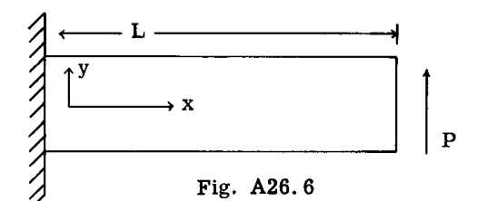

図 A26.6

前述の例と同じ基本仮定がなされ、基本方程式も同じである。作用するモーメント $M$ が次式で与えられるとき、境界条件方程式は同じである。

$$M = P(L - x)$$

ひずみ分布が再び次の形式であると仮定する。

$$\varepsilon_x = (C_0 + C_1 y)g(x)$$

$$\varepsilon_y = f(y)$$

$$\varepsilon_z = 0$$

$\varepsilon_x$ に対する仮定は、曲げ作用が支配的である梁に議論を限定するため、この場合により意味がある。これは、この仮定の下で開発された解が $L \gg d$ である梁にのみ適用されることを意味する。梁に沿った1つのステーション、すなわち $x$ の1つの値を考え、まず境界条件方程式を考える。第1の式、すなわち

$$\int_{-\frac{d}{2}}^{\frac{d}{2}} \sigma_x t dy = 0$$

から、前と同様に $C_0 = 0$ が従う。

第2の式から、そして $C_1 g(x) = C_2(x)$ と置くと、

$$E C_2 \int_{-\frac{d}{2}}^{\frac{d}{2}} t y^2 dy + P(L - x) = 0$$

したがって

$$C_2 = -\frac{P(L - x)}{EI}$$

となるので、

$$\sigma_x = -\frac{P(L - x)}{I} y$$

第1の平衡方程式から次のように従う。

$$\frac{\partial\tau_{xy}}{\partial y} = -\frac{Py}{I}$$

積分により

$$\tau_{xy} = -\frac{Py^2}{2I} + f(x)$$

ここで、梁の上端面および下端面、すなわち $y = \pm \frac{d}{2}$ においてせん断がゼロでなければならないため、直接 $f(x)$ が次式で与えられる定数であることが従う。

$$C_3 = \frac{Pd^2}{8I}$$

したがって、 $\tau_{xy} = \frac{P}{2I} \left( \frac{d^2}{4} - y^2 \right)$ となる。

第2の平衡方程式から次のように従う。

$$\frac{\partial\sigma_y}{\partial y} = 0$$

したがって、前述の例と同じ議論から、次のように従う。

$$\sigma_y = 0$$

ひずみ分布は、フックの法則と仮定から直接得られ、次のようになる。

$$\varepsilon_z = \gamma_{xz} = \gamma_{yz} = 0$$

$$\varepsilon_x = -\frac{P}{EI}(L - x)y$$

$$\varepsilon_y = +\frac{
u P}{EI}(L - x)y$$

$$\gamma_{xy} = \frac{P}{2IG} \left( \frac{d^2}{4} - y^2 \right)$$

これらのひずみ成分は、明らかに適合方程式を満たす。

変位分布は、以下のようにひずみ-変位関係から得ることができる。

$$\varepsilon_x = \frac{\partial u}{\partial x} = -\frac{P}{EI}(L - x)y$$

であるから、次のように従う。

$$u = -\frac{PLyx}{EI} + \frac{Px^2 y}{2EI} + f(y)$$

また、 $\varepsilon_y = \frac{\partial v}{\partial y} = \frac{ u P}{EI}(L - x)y$ であるから、

$$v = k(x) + \frac{
u P}{EI}(L - x) \frac{y^2}{2}$$

$x = 0$ で $u = 0$ であるため、直接 $f(y) = 0$ が従う。第3のひずみ-変位関係、すなわち

$$\gamma_{xy} = \frac{\partial u}{\partial y} + \frac{\partial v}{\partial x}$$

から、直接代入することにより、次のように従う。

$$\frac{P}{2IG} \left( \frac{d^2}{4} - y^2 \right) = -\frac{PLx}{EI} + \frac{Px^2}{2EI} + \frac{dv}{dx}$$

我々は中立軸のたわみ、すなわち $v(x, y = 0)$ のプロットのみに興味があるため、この方程式を次のように書き直すことができる。

$$\frac{dv}{dx} = \frac{Pd^2}{8IG} + \frac{PLx}{EI} - \frac{Px^2}{2EI}$$

したがって、 $x = 0$ で $\frac{dv}{dx} = 0$ という境界条件を課す。

積分し、 $x = 0$ で $v = 0$ という境界条件を満たすと、中立軸の変形の一般式は次のように得られる。

$$v = \frac{Pxd^2}{8IG} - \frac{Px^3}{6EI} + \frac{PLx^2}{2EI}$$

そして、先端におけるたわみは次のようになる。

$$v_{x=L} = \frac{PL^3}{3EI} + \frac{PLd^2}{8IG}$$

この解が材料力学アプローチから開発されたものと異なることは興味深い。 $\frac{PLd^2}{8IG}$ という項はせん断力から生じ、事実上、次式で与えられる $x = 0$ 端における回転である。

$$\left. \frac{\partial v}{\partial x} \right|_{\begin{aligned} x&=0 \\ y&=0 \end{aligned}} = \frac{Pd^2}{8IG}$$

この回転が防止される場合、この場合の先端のたわみは次のようになるべきである。

$$v_{\begin{aligned} y&=0 \\ x&=L \end{aligned}} = \frac{PL^3}{3EI}$$

これは、ステーション $x = 0$ において境界条件を課した場合の解であったはずである。

$$\left. \frac{\partial v}{\partial x} \right|_{\begin{aligned} x&=0 \\ y&=0 \end{aligned}} = 0$$

固定端は自由に変形できないため、上記で得られた変位分布、したがって固定端の近傍における応力およびひずみ分布は、上記で得られたものとはならない。解は、すべての点 $x > d$ で梁全体にわたって有効である（サンブナンの原理）。また、解が自由端の近傍で有効であるためには、せん断荷重 $P$ がせん断分布に従って加えられなければならないことも言及しておくべきである。

$$\frac{P}{2I} \left( \frac{d^2}{4} - y^2 \right)$$

これが満たされない場合、解は自由端の領域には適用されない。

この固定端の境界条件の問題は、より多くの研究に値するため、次の例で議論される。さらに徹底的な議論については、参考文献1を参照されたい。

### 例3

前述の例において、応力分布は次のように得られた。

$$\sigma_x = -\frac{P(L - x)y}{I}$$

$$\sigma_y = 0$$

$$\tau_{xy} = \frac{P}{2I} \left( \frac{d^2}{4} - y^2 \right)$$

$$\varepsilon_x = -\frac{P}{EI}(L - x)y$$

$$\varepsilon_y = \frac{
u P}{EI}(L - x)y$$

$$\gamma_{xy} = \frac{P}{2IG} \left( \frac{d^2}{4} - y^2 \right)$$

そして、ひずみ-変位関係から、

$$u = -\frac{Pxy}{EI} \left( L - \frac{x}{2} \right) + f(y)$$

$$v = \frac{
u P}{2EI}(L - x)y^2 + g(x)$$

ここで $f(y)$ および $g(x)$ は、それぞれ $y$ および $x$ のみの関数である。この例の目的は、これらの関数を例2で行ったよりも一般的な意味で評価することである。第3のひずみ-変位関係、すなわち

$$\gamma_{xy} = \frac{\partial u}{\partial y} + \frac{\partial v}{\partial x}$$

に $u$ および $v$ の式を代入すると、次式が得られる。

$$\frac{P}{2IG} \left( \frac{d^2}{4} - y^2 \right) = -\frac{Px}{EI} \left( L - \frac{x}{2} \right) + f'(y) - \frac{
u P y^2}{2EI} + g'(x)$$

ここで $f'(y) = \frac{df}{dy}$ および $g'(x) = \frac{dg}{dx}$ である。

この方程式は $x$ および $y$ のすべての値に対して成立しなければならないため、交互に $x$ および $y$ をゼロにすることによって、関数 $f'(y)$ および $g'(x)$ の性質を調べることができる。 $y = 0$ に対して、

$$\frac{Pd^2}{8IG} = -\frac{Px}{EI} \left( L - \frac{x}{2} \right) + f'(0) + g'(x)$$

$x = 0$ に対して、

$$\frac{P}{2IG} \left( \frac{d^2}{4} - y^2 \right) = f'(y) - \frac{
u P y^2}{2EI} + g'(0)$$

$x = 0, y = 0$ に対して、

$$\frac{Pd^2}{8IG} = f'(0) + g'(0)$$

今、 $f'(0)$ および $g'(0)$ は定数 $C_1$ および $C_2$ である。したがって、

$$g'(x) = \frac{Pd^2}{8IG} + \frac{Px}{EI} \left( L - \frac{x}{2} \right) - C_1$$

$$f'(y) = \frac{P}{2IG} \left( \frac{d^2}{4} - y^2 \right) + \frac{
u P y^2}{2EI} - C_2$$

直接積分により、次のようになる。

$$g(x) = \frac{Pd^2 x}{8IG} + \frac{Px^2 L}{2EI} - \frac{Px^3}{6EI} - C_1 x + C_3$$

$$f(y) = \frac{P}{2IG} \left( \frac{d^2 y}{4} - \frac{y^3}{3} \right) + \frac{
u P y^3}{6EI} - C_2 y + C_4$$

したがって、 $u$ および $v$ の完全な式は次のようになる。

$$u = -\frac{Pxy}{EI} \left( L - \frac{x}{2} \right) + \frac{P}{2IG} \left( \frac{d^2 y}{4} - \frac{y^3}{3} \right) + \frac{
u P y^3}{6EI} - C_2 y + C_4$$

$$v = \frac{
u P}{2EI}(L - x)y^2 + \frac{Pd^2 x}{8IG} + \frac{Px^2 L}{2EI} - \frac{Px^3}{6EI} - C_1 x + C_3$$

ここで、端部 $x = 0$ で梁を固定するには、 $u$ および $v$ 方向の並進を防ぎ、この端部での回転を防ぐ必要がある。したがって、端部条件は次のように書くことができる。

$$u(0,0) = v(0,0) = 0$$

かつ

$$\left. \frac{\partial u}{\partial y} \right|_{x=0, y=0} = 0$$

または

$$\left. \frac{\partial v}{\partial x} \right|_{x=0, y=0} = 0$$

これらの方程式に加えて、さらに次の関係式が必要である。

$$\frac{Pd^2}{8IG} = C_1 + C_2$$

これらから $C_1, C_2, C_3$ および $C_4$ を評価する。したがって、境界条件は過剰規定されており、3つの異なるセットを選択することによって、変位分布に対して異なる解を得ることができる。しかし、並進は許されないため、選択肢は2つだけである。条件を含むセットに対する解は、

$$\left. \frac{\partial u}{\partial y} \right|_{x=0, y=0} = 0$$

であり、これは例2のものである。したがって、条件を含むセットを考えてみよう。

$$\left. \frac{\partial v}{\partial x} \right|_{x=0, y=0} = 0$$

これらの条件を適用し、 $C_1$ および $C_2$ の他の方程式を使用すると、変位に対して次の解が得られる。

$$u = -\frac{Pxy}{EI} \left( L - \frac{x}{2} \right) + \frac{P}{2IG} \left( \frac{d^2 y}{4} - \frac{y^3}{3} \right) + \frac{
u P y^3}{6EI}$$

$$v = \frac{
u P}{2EI}(L - x)y^2 + \frac{Px^2 L}{2EI} - \frac{Px^3}{6EI}$$

そして、 $y = 0, x = L$ における先端のたわみは次のようになることに注意されたい。

$$v = \frac{PL^3}{3EI}$$

### 例4

次に、図 26.7 に示すように、外部から等分布荷重を受けた同じ梁を考える。

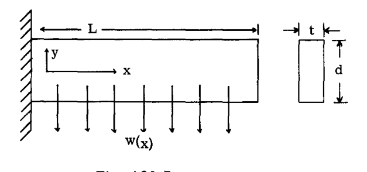

図 A26.7

作用する荷重による応力場の局所的な影響を無視し、したがってすべての $y$ の値に対して $\sigma_y = 0$ であるという議論を維持するのが一般的な工学的慣行である。唯一のゼロでない応力成分は、したがって $\sigma_x$ および $\tau_{xy}$ である。したがって、解決技術は前述の例と同じであるが、ここでは示された座標系に対してモーメント $M$ が次の形式で与えられる。

$$M(x) = \int_0^{L-x} w(x) a da$$

解は、前述の例のステップに直接従う。大部分の問題において、 $w$ の梁に沿った変化は線形であるか、一連の離散荷重にまとめられているか、または $w$ が定数である。これらのいずれの場合でも、この積分は問題解決の初期段階で容易に評価される。たとえば、 $w = \text{定数}$ の場合、

$$M(x) = \frac{w}{2}(L - x)^2$$

であり、応力場は次式で与えられる。

$$\sigma_x = -\frac{w(L - x)^2}{2EI} y$$

$$\sigma_y = 0$$

$$\tau_{xy} = \frac{w(L - x)}{2EI} \left[ \frac{d^2}{4} - y^2 \right]$$

そして変位は前と同様に決定される。

しかし、実際のarad問題は、梁の上端面および下端面が応力フリーであると考えられる上記解ほど単純ではない。図に示すように作用する荷重は、これらの面の一方または両方で $\sigma_y$ がゼロでなくなることを要求する。実際、3つの応力成分 $\sigma_x, \sigma_y$ および $\tau_{xy}$ すべてが梁全体でゼロではなくなる。解は単純ではないが、読者は今やそれを攻撃する技術を持っている。解は、 $\sigma_y$ が載荷面でゼロではなくなる上端面および下端面に沿った境界条件を注意深く観察しながら、前と同じステップに従う。この問題の最も単純な例は、 $w$ が梁に沿って定数である場合である。この場合、定数荷重が下面に吊り下げられており、境界条件

$$\sigma_y = w, \quad y = -\frac{d}{2} \text{ において}$$

が生じるとき、応力成分が次のようになることを示すことは、読者への演習として残されている。

$$\sigma_x = \frac{wt}{I} y(L - x)^2 - \frac{wt}{I} \frac{y^3}{3} + \frac{wt}{I} \frac{d^2}{20} y$$

$$\sigma_y = -\frac{wt}{I} \frac{y^3}{6} - \frac{wt}{8I} d^2 y + \frac{wtd^3}{124}$$

$$\tau_{xy} = \frac{wt}{I}(L - x) \frac{y^2}{2} - \frac{wt}{I}(L - x) \frac{d^2}{8}$$

そして、中立軸のたわみは次式で与えられる。

$$\begin{aligned}
\bar{v} &= -\frac{wt}{GI} \left\{ Lx - \frac{x^2}{2} \right\} \frac{d^2}{8} - \frac{wt}{EI} \left\{ \frac{L^2 x^2}{4} - \frac{Lx^3}{6} + \frac{x^4}{24} \right\} \\
&\quad - \frac{wt}{EI} \frac{d^2}{40} x^2 - \frac{
u wt}{EI} \frac{d^2}{16} x^2 + \frac{1}{GI} \frac{wt d^2}{8} Lx
\end{aligned}$$

**一般注記**: 我々は線形問題を扱っているため、与えられた荷重を上記の問題の荷重と一致する成分に分解し、これらの成分荷重に対応する個別の解を直接重ね合わせることによって、複雑な複合荷重状態に対する最終的な解を得ることが可能である。この一般的な手法は、梁の一般的な熱弾性問題に対する解を得るために使用される。

### 例5

深さ方向には非線形な温度分布を持ち、スパン方向には一定である、すなわち $T = T(y)$ である片持ち梁を考える。この一般的な分布は、高速航空機の翼における温度分布の近似である。

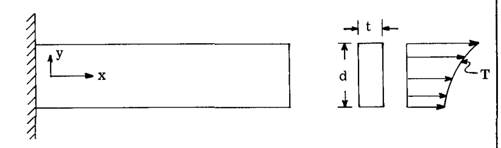

温度分布

**仮定**: (i) A25章で議論された基本理論を支配する仮定。 (ii) $\sigma_y = \tau_{xy} = \sigma_y = 0$ 。 (iii) 根元（ $x = 0$ ）における変形 $v$ に対する拘束は無視できる。根元の固定を考慮する場合、この仮定は疑問である。 $v$ に対する根元拘束を含めることの影響は、 $v$ を拘束するために自己平衡等温応力パターンを重ね合わせることによって評価できる。その影響は、梁の根元の局所的な領域（ $L \gg d$ ）においてのみ顕著であり、したがって無視される。 (iv) 材料特性は温度に依存しない。

**基本方程式**:（再びA25章を参照のこと。） 端面に沿って境界力がなく、根元位置での膨張に対する抵抗がないと仮定されるため、 $\tau_{xy} = 0$ となる。また、この熱荷重のみの場合、 $\sigma_x$ は $y$ のみの関数（スパン方向に一定の $\sigma_x$ ）になることも今や明らかである。

適合方程式（式 25.12 参照）は、したがって次のように減少する。

$\sigma_x$ および $T$ は $y$ のみの関数であるため、この方程式はさらに常微分方程式に減少する。

$$\frac{d^2}{dy^2}(\sigma_x + E\alpha T) = 0$$

**境界条件**: 片持ち梁は、根元における $x$ 方向の対称なゼロ変形の条件を満たすために、長さ $2L$ の梁に置き換えられる。この梁では、すべての表面がゼロでなければならない。したがって、 $\sigma_x$ に対する境界条件は次のように書くことができる。

1. $x = \pm L$ における端面上の結果としての力はゼロである、すなわち

$$\int_{-\frac{d}{2}}^{\frac{d}{2}} \sigma_x t dy = 0$$

2. これらの面上の結果としてのモーメントはゼロでなければならない、すなわち

$$\int_{-\frac{d}{2}}^{\frac{d}{2}} \sigma_x t y dy = 0$$

**解**: 一般解は、直接積分によって次のように得られる。

$$\sigma_x = -E\alpha T + C_1 y + C_2$$

境界条件を使用すると、次のように $C_1$ および $C_2$ を評価できる。

$$C_1 = \frac{12\alpha E}{d^3} \int_{-\frac{d}{2}}^{\frac{d}{2}} T y dy$$

$$C_2 = \frac{\alpha E}{d} \int_{-\frac{d}{2}}^{\frac{d}{2}} T dy$$

したがって、任意のステーションにおける応力分布は次式で与えられる。

$$\sigma_x = \alpha E \left[ -T + \frac{1}{d} \int_{-\frac{d}{2}}^{\frac{d}{2}} T dy + \frac{12}{d^3} y \int_{-\frac{d}{2}}^{\frac{d}{2}} T y dy \right] \quad \text{--- Eq. (A)}$$

そして、 $\sigma_y = 0$ とした一般的な応力-ひずみ関係から直接次のように従う。

$$\varepsilon_x = \alpha \left[ \frac{1}{d} \int_{-\frac{d}{2}}^{\frac{d}{2}} T dy + \frac{12}{d^3} y \int_{-\frac{d}{2}}^{\frac{d}{2}} T y dy \right]$$

および

$$\varepsilon_y = -
u \alpha \left[ \frac{1}{d} \int_{-\frac{d}{2}}^{\frac{d}{2}} T dy + \frac{12}{d^3} y \int_{-\frac{d}{2}}^{\frac{d}{2}} T y dy \right] + \alpha T(1 +
u)$$

$$\gamma_{xy} = 0$$

そして、 $x = 0$ で $u = 0$ の境界条件を満たすひずみ-変位関係の直接積分によって得られる変位は、以下のようになる。

$$u = \alpha x \left[ \frac{1}{d} \int_{-\frac{d}{2}}^{\frac{d}{2}} T dy + \frac{12}{d^3} y \int_{-\frac{d}{2}}^{\frac{d}{2}} T y dy \right]$$

再び、我々は「中立」軸の変形、またはこの場合は任意のライン $y = \text{定数}$ における変形に興味がある。 $\gamma_{xy} = 0$ であるため、ひずみ-変位関係から次のように従う。

$$\frac{\partial v}{\partial x} = -\frac{\partial u}{\partial y}$$

および

$$\frac{\partial^2 v}{\partial x^2} = -\frac{\partial^2 u}{\partial x\partial y} = -\alpha \frac{12}{d^3} \int_{-\frac{d}{2}}^{\frac{d}{2}} T y dy = \text{定数}$$

したがって、曲率は梁の長さに沿って一定であり、 $v$ は次式の値の有効な端部モーメントによるものと考えることができる。

$$\alpha E \frac{12}{d^3} y \int_{-\frac{d}{2}}^{\frac{d}{2}} T y dy$$

したがって、解は完了する。

### 例6

前述の問題は、もちろん、A25章に概説されている応力関数 $\phi$ に関する逆定式化を用いて解決することもできる。

温度勾配は $y$ のみの関数として選択されており、 $\sigma_y = 0$ であるため、 $\phi$ は $y$ のみの関数となる。一般方程式

は、次のように減少する。

$$\frac{d^4 \phi}{dy^4} = -E\alpha \frac{d^2 T}{dy^2}$$

$y$ に関して両辺を積分すると、次式が得られる。

$$\phi = -QE \int \int T dy dy + C_1 y^3 + C_2 y^2 + C_3 y + C_4$$

そして、 $C_1, C_2, C_3$ および $C_4$ の評価に必要な $\phi$ に関する境界条件は、A25章から境界において $\phi = \frac{d\phi}{dy} = 0$ として従う。

$$y = \pm \frac{d}{2}$$

応力は、次式から直接得ることができる。

$$\sigma_x = \frac{d^2 \phi}{dy^2}$$

そして、ひずみと変位は前述の例と同様に得られる。

### 例7 数値例

以下の寸法と材料特性を持つ片持ち梁を考える。

$$L = 10 \text{ ins.}, \quad \alpha = 7 \times 10^{-6}$$

$$d = 2 \text{ ins.}, \quad E = 30 \times 10^6 \text{ (定数と仮定)}$$

$$t = \frac{1}{8} \text{ ins.}, \quad
u = 0.3$$

そして、以下の弦方向の温度勾配を受ける。

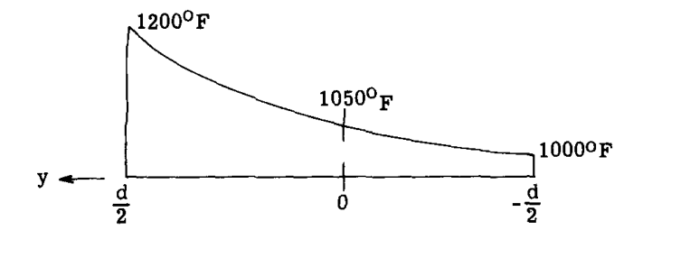

温度勾配

放物線状の温度分布を仮定すると、次のようになる。

$$T(y) = 50y^2 + 100y + 1050$$

すると、

$$\int_{-1}^1 T dy = 2133 \quad ; \quad \int_{-1}^1 T y dy = 66$$

したがって、式Aから、

$$\sigma_x = 210(-50y^2 + 16)$$

したがって、

$$\left. \sigma_x \right|_{y = \pm \frac{d}{2}} = -6,740 \text{ lb./ins.}^2 \quad \text{圧縮}$$

$$\left. \sigma_x \right|_{y = 0} = 3360 \text{ lb./ins.}^2 \quad \text{引張}$$

2つの対称なノードは次の位置になる。

$$y = \pm \left( \frac{16}{50} \right)^{1/2} = \pm 0.57 \text{ ins.}$$

応力プロファイルは、したがって、プロットに示されているように、ほぼ（解の数値は近似値である）対称である。

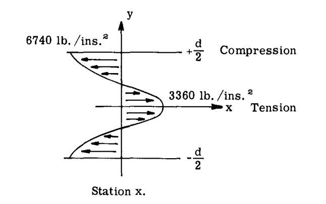

応力プロファイル

境界 $x = \pm L$ におけるゼロ法線応力の境界条件が満たされていないことに注意すべきである。得られた解は、サンブナンの原理に従って、範囲 $x = \pm(L - d)$ においてのみ有効である。解を範囲 $-L < x < L$ 全体に拡張する場合、法線応力のバランスをとるために、端部に自己平衡応力分布を適用しなければならない。これは困難な問題であり、本議論の範囲を超えている。

### 例8

A25章の議論に従って、梁が外荷重と弦方向に変化する温度分布を受ける場合の単純な梁の問題に対する解を、別々の解の直接重ね合わせを用いることによって得ることが可能になった。たとえば、外荷重が端部モーメント $M$ であり、温度分布が深さ方向に線形であり、 $T(y) = A + By$ で与えられる単純な片持ち梁の場合を考える。応力成分は次式で与えられる。

$$\sigma_x = \sigma_{x_1} \text{（モーメント M による）} + \sigma_{x_2} \text{（温度による）}$$

$$\sigma_y = 0$$

$$\tau_{xy} = 0$$

そして変位は

$$u = u_1 \text{（モーメント M による）} + u_2 \text{（温度による）}$$

$$v = v_1 \text{（モーメント M による）} + v_2 \text{（温度による）}$$

次のように示すことは、読者への演習として残されている。

$$\sigma_{x_1} = -\frac{My}{I}$$

$$\sigma_{x_2} = 0$$

$$u_1 = -\frac{Myx}{EI}$$

$$u_2 = \alpha(A + By)x$$

$$v_1 = -\frac{M}{2EI}(x^2 +
u y^2)$$

$$v_2 = \alpha y \left( A + \frac{1}{2} By \right) - \frac{1}{2} \alpha B x^2$$

## 結言

上記に示された例は、二次元弾性問題がどのように攻撃されるか、また複雑な荷重状態を伴う問題が、荷重状態のより単純な個別の成分を考慮し、重ね合わせを用いることによって最終的な解を得ることによって、どのように単純化できるかを示している。この技術は、熱応力を扱う問題においてさらに説明される。

一般の三次元弾性問題から二次元の平面応力または平面ひずみ問題への単純化は、慎重に行わなければならず、この理想化の結果は、大部分の問題において見落とされてはならないことを念頭に置くべきである。

本章で提示されたすべての例示問題は、弾性および熱弾性の理論においてはほとんど数学的に些細な問題である。我々は、梁の深さが長さに比べて小さく、温度が深さ方向にのみ変化する単純な梁の問題に注目を限定してきた。しかし、基本方程式および解決技術は、温度が2つの空間座標の関数である $T = T(x, y)$ であり、幾何形状が一般的な二次元板のものである、より複雑な問題の解決にとって基本的である。これらの問題では、すべての応力成分が存在し、一般的な二次元板問題において $z$ 方向の変位が発生する可能性がある。この種の問題においてここで示された技術の一般化は、本議論の範囲を超えており、この主題を追求したい読者は、次に示す文献を参照されたい。これらは今や容易に読むことができる。

熱弾性に関するすべての先行の議論に不可欠であり、引用された文献に固有の重要な仮定は、「熱機械的結合」が存在しないことである。これにより、機械的応答との相互結合なしに（運動学的変数を含めることなく）、温度場を別個の問題として計算することができ、この温度分布による弾性問題は個別に考慮することができる。この仮定は、関与する速度プロセスが遅い場合にのみ有効である。

## 参考文献

1. Boley, Bruno A. and Weiner, Jerome H., “Theory of Thermal Stresses”. John Wiley & Sons, New York, 1960.
2. Gatewood, B. E., “Thermal Stresses” with Application to Airplanes, Missiles, Turbines and Nuclear Reactors. McGraw Hill, New York, 1957.
3. Timoshenko, S. H. and Goodier, J. N., “Theory of Elasticity”, 2nd Ed., Chapter 14, McGraw Hill, New York, 1951.
4. Sokolinkoff, I. S., “Mathematical Theory of Elasticity”, 2nd Ed., Section 101, McGraw Hill, New York, 1956.